# Relationship Pursuit Study

PSY 120L Reproducible Analysis Report

Author

Kanishk Bhatnagar

Published

June 11, 2026

## About This Report

This report explains how the relationship study data were cleaned, scored, analyzed, and visualized.

## Study Overview

This study looks at how relationship context affects the traits people value in a romantic partner. Participants were placed in either a short-term or long-term relationship condition and rated partner traits. The analyses also examine sex and commitment readiness.

## Setup and Software Environment

This section loads the R packages needed for data cleaning, reliability checks, ANOVAs, estimated means, and figures.

**Load Packages**

```r
library(tidyverse)  # data manipulation + plotting
library(psych)      # scale construction + reliability
library(afex)       # ANOVA models + effect sizes
library(emmeans)    # estimated marginal means + confidence intervals
```

## Data Source and Analysis Dataset

This section imports the raw data and creates a smaller dataset with only the variables needed for analysis.

### Import Dataset

```r
study_raw <- read_csv("data/relationship_pursuit_data.csv")
```

### Check Imported Dataset

```r
dim(study_raw)
```

```
[1] 71 35
```

```r
names(study_raw)
```

```
 [1] "ResponseId"           "DistributionChannel"  "consent"
 [4] "Long_Term_Traits_1"   "Long_Term_Traits_2"   "Long_Term_Traits_3"
 [7] "Long_Term_Traits_4"   "Long_Term_Traits_5"   "Long_Term_Traits_6"
[10] "Long_Term_Traits_7"   "Long_Term_Traits_8"   "Long_Term_Traits_9"
[13] "Long_Term_Traits_10"  "Short_Term_Traits_1"  "Short_Term_Traits_2"
[16] "Short_Term_Traits_3"  "Short_Term_Traits_4"  "Short_Term_Traits_5"
[19] "Short_Term_Traits_6"  "Short_Term_Traits_7"  "Short_Term_Traits_8"
[22] "Short_Term_Traits_9"  "Short_Term_Traits_10" "check"
[25] "Commit_1"             "Commit_2"             "Commit_3"
[28] "Commit_4"             "Commit_5"             "Commit_6"
[31] "Commit_7"             "Commit_8"             "age"
[34] "sex"                  "condition"
```

```r
head(study_raw)
```

```
# A tibble: 6 × 35
  ResponseId   DistributionChannel consent Long_Term_Traits_1 Long_Term_Traits_2
  <chr>        <chr>                 <dbl>              <dbl>              <dbl>
1 R_5DqGp4GTV… email                     1                 NA                 NA
2 R_5FjKOfBut… email                     1                  7                  7
3 R_12EXz22Ua… email                     1                 NA                 NA
4 R_10wYoD2Qc… anonymous                 1                 NA                 NA
5 R_3EiuvYYtL… anonymous                 1                  7                  7
6 R_1MSSHU33V… anonymous                 1                  7                  7
# ℹ 30 more variables: Long_Term_Traits_3 <dbl>, Long_Term_Traits_4 <dbl>,
#   Long_Term_Traits_5 <dbl>, Long_Term_Traits_6 <dbl>,
#   Long_Term_Traits_7 <dbl>, Long_Term_Traits_8 <dbl>,
#   Long_Term_Traits_9 <dbl>, Long_Term_Traits_10 <dbl>,
#   Short_Term_Traits_1 <dbl>, Short_Term_Traits_2 <dbl>,
#   Short_Term_Traits_3 <dbl>, Short_Term_Traits_4 <dbl>,
#   Short_Term_Traits_5 <dbl>, Short_Term_Traits_6 <dbl>, …
```

The output above checks that the raw dataset imported correctly.

### Create Analysis Dataset

```r
study_vars <- c(
     "condition", "check", "sex","age",

     "Commit_1","Commit_2","Commit_3","Commit_4",
     "Commit_5","Commit_6","Commit_7","Commit_8",

      "Long_Term_Traits_1","Long_Term_Traits_2","Long_Term_Traits_3",
      "Long_Term_Traits_4","Long_Term_Traits_5","Long_Term_Traits_6",
      "Long_Term_Traits_7","Long_Term_Traits_8","Long_Term_Traits_9",
      "Long_Term_Traits_10",

      "Short_Term_Traits_1","Short_Term_Traits_2","Short_Term_Traits_3",
      "Short_Term_Traits_4","Short_Term_Traits_5","Short_Term_Traits_6",
       "Short_Term_Traits_7","Short_Term_Traits_8","Short_Term_Traits_9",
      "Short_Term_Traits_10" # Short-term items

      )

study_data <- study_raw %>%
  select(all_of(study_vars)) %>%
  mutate(
    across(everything(), as.numeric)
  )
```

### Check Analysis Dataset

```r
length(study_vars)
```

```
[1] 32
```

```r
dim(study_data)
```

```
[1] 71 32
```

```r
names(study_data)
```

```
 [1] "condition"            "check"                "sex"
 [4] "age"                  "Commit_1"             "Commit_2"
 [7] "Commit_3"             "Commit_4"             "Commit_5"
[10] "Commit_6"             "Commit_7"             "Commit_8"
[13] "Long_Term_Traits_1"   "Long_Term_Traits_2"   "Long_Term_Traits_3"
[16] "Long_Term_Traits_4"   "Long_Term_Traits_5"   "Long_Term_Traits_6"
[19] "Long_Term_Traits_7"   "Long_Term_Traits_8"   "Long_Term_Traits_9"
[22] "Long_Term_Traits_10"  "Short_Term_Traits_1"  "Short_Term_Traits_2"
[25] "Short_Term_Traits_3"  "Short_Term_Traits_4"  "Short_Term_Traits_5"
[28] "Short_Term_Traits_6"  "Short_Term_Traits_7"  "Short_Term_Traits_8"
[31] "Short_Term_Traits_9"  "Short_Term_Traits_10"
```

The output above confirms that the analysis dataset contains the correct number of variables and the expected column names.

## Variable Preparation

This section prepares the main variables by creating participant IDs, labeling condition and sex, reverse-coding items, combining trait items, and creating scale scores.

### Prepare Participant ID and Experimental Condition

```r
study_data <- study_data %>%
  mutate(
    id = row_number(),
    condition = factor(
      condition,
      levels = c(0, 1),
      labels = c("Short-Term", "Long-Term")
    ),
    sex = case_when(
      sex == 1 ~ "Male",
      sex == 2 ~ "Female",
      TRUE ~ NA_character_
    ),
    sex = factor(
      sex,
      levels = c("Female", "Male")
    )
  )
```

This code creates an ID for each participant and recodes condition and sex into readable factor labels.

### Check Experimental Condition Coding

```r
study_data %>%
  count(condition) %>%
  knitr::kable(
    col.names = c("Condition", "n")
  )
```

| Condition | n |
| --- | --- |
| Short-Term | 34 |
| Long-Term | 35 |
| NA | 2 |

```r
study_data %>%
  count(sex) %>%
  knitr::kable(
    col.names = c("Sex", "n")
  )
```

| Sex | n |
| --- | --- |
| Female | 57 |
| Male | 8 |
| NA | 6 |

The tables above check how many participants are in each condition and sex group.

### Check Prepared Analysis Dataset

```r
dim(study_data)
```

```
[1] 71 33
```

```r
names(study_data)
```

```
 [1] "condition"            "check"                "sex"
 [4] "age"                  "Commit_1"             "Commit_2"
 [7] "Commit_3"             "Commit_4"             "Commit_5"
[10] "Commit_6"             "Commit_7"             "Commit_8"
[13] "Long_Term_Traits_1"   "Long_Term_Traits_2"   "Long_Term_Traits_3"
[16] "Long_Term_Traits_4"   "Long_Term_Traits_5"   "Long_Term_Traits_6"
[19] "Long_Term_Traits_7"   "Long_Term_Traits_8"   "Long_Term_Traits_9"
[22] "Long_Term_Traits_10"  "Short_Term_Traits_1"  "Short_Term_Traits_2"
[25] "Short_Term_Traits_3"  "Short_Term_Traits_4"  "Short_Term_Traits_5"
[28] "Short_Term_Traits_6"  "Short_Term_Traits_7"  "Short_Term_Traits_8"
[31] "Short_Term_Traits_9"  "Short_Term_Traits_10" "id"
```

The output above confirms that the prepared dataset includes the new recoded variables.

### Reverse-Code Scale Items

Some items are reverse-coded so that higher scores consistently mean higher levels of the measured construct.

```r
study_data <- study_data %>%
  mutate(

    Commit_2r  = 8 - Commit_2,
    Commit_4r  = 8 - Commit_4,
    Commit_6r = 8 - Commit_6,
    Commit_8r = 8 - Commit_8,

    Long_Term_Traits_3r  = 8 - Long_Term_Traits_3,
    Long_Term_Traits_4r  = 8 - Long_Term_Traits_4,
    Long_Term_Traits_6r = 8 - Long_Term_Traits_6,
    Long_Term_Traits_7r = 8 - Long_Term_Traits_7,
    Long_Term_Traits_10r = 8 - Long_Term_Traits_10,

    Short_Term_Traits_3r  = 8 - Short_Term_Traits_3,
    Short_Term_Traits_4r  = 8 - Short_Term_Traits_4,
    Short_Term_Traits_6r = 8 - Short_Term_Traits_6,
    Short_Term_Traits_7r = 8 - Short_Term_Traits_7,
    Short_Term_Traits_10r = 8 - Short_Term_Traits_10


  )
```

### Check Reverse Coding

```r
study_data %>%
  select(
    Commit_2, Commit_2r,
    Long_Term_Traits_3, Long_Term_Traits_3r,
    Short_Term_Traits_3, Short_Term_Traits_3r
  ) %>%
  head(10) %>%
  knitr::kable()
```

| Commit_2 | Commit_2r | Long_Term_Traits_3 | Long_Term_Traits_3r | Short_Term_Traits_3 | Short_Term_Traits_3r |
| --- | --- | --- | --- | --- | --- |
| 3 | 5 | NA | NA | 5 | 3 |
| 5 | 3 | 7 | 1 | NA | NA |
| 1 | 7 | NA | NA | 5 | 3 |
| 5 | 3 | NA | NA | 5 | 3 |
| 1 | 7 | 4 | 4 | NA | NA |
| 1 | 7 | 5 | 3 | NA | NA |
| 1 | 7 | NA | NA | 7 | 1 |
| 1 | 7 | 4 | 4 | NA | NA |
| 3 | 5 | NA | NA | 7 | 1 |
| 1 | 7 | 5 | 3 | NA | NA |

### Combine Trait Responses

```r
study_data <- study_data %>%
  mutate(
    trait_1  = coalesce(Long_Term_Traits_1,  Short_Term_Traits_1),
    trait_2  = coalesce(Long_Term_Traits_2,  Short_Term_Traits_2),
    trait_3  = coalesce(Long_Term_Traits_3r, Short_Term_Traits_3r),
    trait_4  = coalesce(Long_Term_Traits_4r, Short_Term_Traits_4r),
    trait_5  = coalesce(Long_Term_Traits_5,  Short_Term_Traits_5),
    trait_6  = coalesce(Long_Term_Traits_6r, Short_Term_Traits_6r),
    trait_7  = coalesce(Long_Term_Traits_7r, Short_Term_Traits_7r),
    trait_8  = coalesce(Long_Term_Traits_8,  Short_Term_Traits_8),
    trait_9  = coalesce(Long_Term_Traits_9,  Short_Term_Traits_9),
    trait_10 = coalesce(Long_Term_Traits_10r, Short_Term_Traits_10r)
  )
```

### Check Trait Variables

```r
study_data %>%
  select(
    condition,
    Long_Term_Traits_1,
    Short_Term_Traits_1,
    trait_1,
    Long_Term_Traits_3r,
    Short_Term_Traits_3r,
    trait_3
  ) %>%
  head(10) %>%
  knitr::kable()
```

| condition | Long_Term_Traits_1 | Short_Term_Traits_1 | trait_1 | Long_Term_Traits_3r | Short_Term_Traits_3r | trait_3 |
| --- | --- | --- | --- | --- | --- | --- |
| Short-Term | NA | 5 | 5 | NA | 3 | 3 |
| Long-Term | 7 | NA | 7 | 1 | NA | 1 |
| Short-Term | NA | 1 | 1 | NA | 3 | 3 |
| Short-Term | NA | 6 | 6 | NA | 3 | 3 |
| Long-Term | 7 | NA | 7 | 4 | NA | 4 |
| Long-Term | 7 | NA | 7 | 3 | NA | 3 |
| Short-Term | NA | 5 | 5 | NA | 1 | 1 |
| Long-Term | 7 | NA | 7 | 4 | NA | 4 |
| Short-Term | NA | 7 | 7 | NA | 1 | 1 |
| Long-Term | 5 | NA | 5 | 3 | NA | 3 |

### Create Scale Scores

The scale scores are created by averaging the commitment items and trait items for each participant.

```r
commit_items <- c("Commit_1", "Commit_2r", "Commit_3", "Commit_4r", "Commit_5", "Commit_6r", "Commit_7", "Commit_8r")

trait_items <- c("trait_1", "trait_2", "trait_3", "trait_4", "trait_5", "trait_6", "trait_7", "trait_8", "trait_9", "trait_10")

study_data <- study_data %>%
  mutate(
    commit_scale = rowMeans(across(all_of(commit_items)), na.rm = TRUE),
    trait_scale = rowMeans(across(all_of(trait_items)), na.rm = TRUE)
  )
```

### Check Scale Scores

```r
study_data %>%
  select(
    commit_scale,
    trait_scale
  ) %>%
  summary()
```

```
  commit_scale    trait_scale
 Min.   :1.000   Min.   :1.700
 1st Qu.:3.871   1st Qu.:3.400
 Median :5.188   Median :4.211
 Mean   :5.022   Mean   :4.086
 3rd Qu.:6.281   3rd Qu.:4.900
 Max.   :7.000   Max.   :5.600
 NA's   :3       NA's   :3
```

```r
study_data %>%
  summarise(
    commit_scale_missing = mean(is.na(commit_scale)),
    trait_scale_missing = mean(is.na(trait_scale))
  ) %>%
  knitr::kable()
```

| commit_scale_missing | trait_scale_missing |
| --- | --- |
| 0.0422535 | 0.0422535 |

The output above summarizes the scale scores and checks whether any scale scores are missing.

```r
commit_median <- median(study_data$commit_scale, na.rm = TRUE)

study_data <- study_data %>%
  mutate(
    commit_msplit = if_else(
      commit_scale <= commit_median,
      "Low Commitment",
      "High Commitment"
    ),
    commit_msplit = factor(
      commit_msplit,
      levels = c("Low Commitment", "High Commitment")
    )
  )

commit_median
```

```
[1] 5.1875
```

```r
study_data %>%
  count(commit_msplit) %>%
  knitr::kable(
    col.names = c("Commitment Group", "n")
  )
```

| Commitment Group | n |
| --- | --- |
| Low Commitment | 34 |
| High Commitment | 34 |
| NA | 3 |

### Check Scale Reliability

Reliability is checked to see whether the items in each scale are internally consistent.

```r
commit_item_df <- study_data %>%
  select(all_of(commit_items))

trait_item_df <- study_data %>%
  select(all_of(trait_items))

commit_alpha <- psych::alpha(commit_item_df)
commit_omega <- psych::omega(commit_item_df, plot = FALSE)

trait_alpha <- psych::alpha(trait_item_df)
```

```
Some items ( trait_7 ) were negatively correlated with the first principal component and
probably should be reversed.
To do this, run the function again with the 'check.keys=TRUE' option
```

```r
trait_omega <- psych::omega(trait_item_df, plot = FALSE)

reliability_table <- tibble(
  scale = c("Commitment", "Traits"),
  alpha = c(
    commit_alpha$total$raw_alpha,
    trait_alpha$total$raw_alpha
  ),
  omega = c(
    commit_omega$omega.tot,
    trait_omega$omega.tot
  )
)

reliability_table %>%
  mutate(
    alpha = round(alpha, 2),
    omega = round(omega, 2)
  ) %>%
  knitr::kable(
    col.names = c("Scale", "Cronbach's alpha", "McDonald's omega")
  )
```

| Scale | Cronbach’s alpha | McDonald’s omega |
| --- | --- | --- |
| Commitment | 0.94 | 0.97 |
| Traits | 0.81 | 0.90 |

The reliability table reports alpha and omega for the commitment and trait scales. Higher values suggest stronger consistency.

## Descriptive Statistics

This section summarizes the main variables and sample characteristics before the main analyses.

### Scale Score Descriptives

```r
# Descriptive statistics for continuous scale variables
psych::describe(
  study_data %>% select(commit_scale, trait_scale)
) %>%
  knitr::kable(digits = 2)
```

|  | vars | n | mean | sd | median | trimmed | mad | min | max | range | skew | kurtosis | se |
| --- | --- | --- | --- | --- | --- | --- | --- | --- | --- | --- | --- | --- | --- |
| commit_scale | 1 | 68 | 5.02 | 1.56 | 5.19 | 5.14 | 1.76 | 1.0 | 7.0 | 6.0 | -0.54 | -0.47 | 0.19 |
| trait_scale | 2 | 68 | 4.09 | 0.98 | 4.21 | 4.14 | 1.02 | 1.7 | 5.6 | 3.9 | -0.56 | -0.75 | 0.12 |

The output above shows the average, spread, and range of the commitment and trait scale scores.

### Sample Composition by Age and Gender

```r
study_data %>%
  summarise(
    mean_age = round(mean(age, na.rm = TRUE), 2),
    sd_age = round(sd(age, na.rm = TRUE), 2),
    min_age = min(age, na.rm = TRUE),
    max_age = max(age, na.rm = TRUE)
  ) %>%
  knitr::kable(
    col.names = c("Mean Age", "SD Age", "Minimum Age", "Maximum Age")
  )
```

| Mean Age | SD Age | Minimum Age | Maximum Age |
| --- | --- | --- | --- |
| 21.26 | 1.14 | 19 | 27 |

```r
study_data %>%
  count(sex) %>%
  mutate(percent = round(100 * n / sum(n), 1)) %>%
  knitr::kable(
    col.names = c("Sex", "n", "Percent")
  )
```

| Sex | n | Percent |
| --- | --- | --- |
| Female | 57 | 80.3 |
| Male | 8 | 11.3 |
| NA | 6 | 8.5 |

The demographic output summarizes the sample’s age and sex.

## Primary Analyses

The primary analyses test whether trait scores differ by relationship condition, sex, and commitment readiness.

### Trait Model Condition × Sex

```r
a1_trait_sex <- afex::aov_ez(
  id = "id",
  dv = "trait_scale",
  between = c("condition", "sex"),
  data = study_data
)

a1_trait_sex
```

```
Anova Table (Type 3 tests)

Response: trait_scale
         Effect    df  MSE         F  ges p.value
1     condition 1, 61 0.49 34.71 *** .363   <.001
2           sex 1, 61 0.49      0.58 .009    .451
3 condition:sex 1, 61 0.49      1.27 .020    .264
---
Signif. codes:  0 '***' 0.001 '**' 0.01 '*' 0.05 '+' 0.1 ' ' 1
```

### Estimated Means for Trait Condition × Sex

```r
emmeans(a1_trait_sex, ~ condition)
```

```
 condition  emmean    SE df lower.CL upper.CL
 Short-Term   3.22 0.187 61     2.85     3.60
 Long-Term    4.78 0.186 61     4.40     5.15

Results are averaged over the levels of: sex
Confidence level used: 0.95
```

```r
emmeans(a1_trait_sex, ~ sex)
```

```
 sex    emmean     SE df lower.CL upper.CL
 Female    4.1 0.0925 61     3.91     4.28
 Male      3.9 0.2470 61     3.41     4.39

Results are averaged over the levels of: condition
Confidence level used: 0.95
```

```r
emmeans(a1_trait_sex, ~ condition * sex)
```

```
 condition  sex    emmean    SE df lower.CL upper.CL
 Short-Term Female   3.47 0.132 61     3.21     3.74
 Long-Term  Female   4.73 0.130 61     4.47     4.99
 Short-Term Male     2.98 0.349 61     2.28     3.67
 Long-Term  Male     4.83 0.349 61     4.13     5.52

Confidence level used: 0.95
```

### Trait Model: Condition × Commitment Model

```r
a2_trait_commit <- afex::aov_ez(
  id = "id",
  dv = "trait_scale",
  between = c("condition", "commit_msplit"),
  data = study_data
)

a2_trait_commit
```

```
Anova Table (Type 3 tests)

Response: trait_scale
                   Effect    df  MSE         F   ges p.value
1               condition 1, 64 0.49 67.22 ***  .512   <.001
2           commit_msplit 1, 64 0.49      1.64  .025    .205
3 condition:commit_msplit 1, 64 0.49      0.00 <.001    .965
---
Signif. codes:  0 '***' 0.001 '**' 0.01 '*' 0.05 '+' 0.1 ' ' 1
```

### Estimated Means for Trait: Condition × Commitment Group

```r
emmeans(a2_trait_commit, ~ condition)
```

```
 condition  emmean    SE df lower.CL upper.CL
 Short-Term   3.37 0.122 64     3.12     3.61
 Long-Term    4.76 0.119 64     4.53     5.00

Results are averaged over the levels of: commit_msplit
Confidence level used: 0.95
```

```r
emmeans(a2_trait_commit, ~ commit_msplit)
```

```
 commit_msplit   emmean    SE df lower.CL upper.CL
 Low Commitment    4.17 0.120 64     3.93     4.41
 High Commitment   3.96 0.121 64     3.71     4.20

Results are averaged over the levels of: condition
Confidence level used: 0.95
```

```r
emmeans(a2_trait_commit, ~ condition * commit_msplit)
```

```
 condition  commit_msplit   emmean    SE df lower.CL upper.CL
 Short-Term Low Commitment    3.48 0.165 64     3.15     3.81
 Long-Term  Low Commitment    4.87 0.175 64     4.52     5.22
 Short-Term High Commitment   3.25 0.181 64     2.89     3.61
 Long-Term  High Commitment   4.66 0.160 64     4.34     4.98

Confidence level used: 0.95
```

## Figures

The figures show the estimated mean trait scores from the ANOVA models.

### Trait: Condition x Sex Interaction Plot

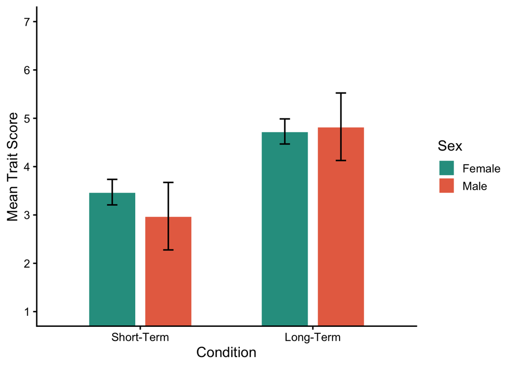

```r
p_trait_condition_sex_bar <- ggplot(
  as.data.frame(emmeans(a1_trait_sex, ~ condition * sex)),
  aes(
    x = condition,
    y = emmean,
    fill = sex
  )
) +
  geom_col(
    position = position_dodge(width = 0.65),
    width = 0.55,
    color = "white"
  ) +
  geom_errorbar(
    aes(
      ymin = lower.CL,
      ymax = upper.CL
    ),
    position = position_dodge(width = 0.65),
    width = 0.12,
    linewidth = 0.7
  ) +
  labs(
    x = "Condition",
    y = "Mean Trait Score",
    fill = "Sex"
  ) +
  scale_fill_manual(
    values = c(
      "Male" = "#E76F51",
      "Female" = "#2A9D8F"
    )
  ) +
  scale_y_continuous(
    breaks = seq(1, 7, 1)
  ) +
  coord_cartesian(
    ylim = c(1, 7)
  ) +
  theme_classic(
    base_size = 14
  )

p_trait_condition_sex_bar
```

This figure shows trait scores by relationship condition and sex, with error bars showing confidence intervals.

### Trait: Condition × Commitment Interaction Plot

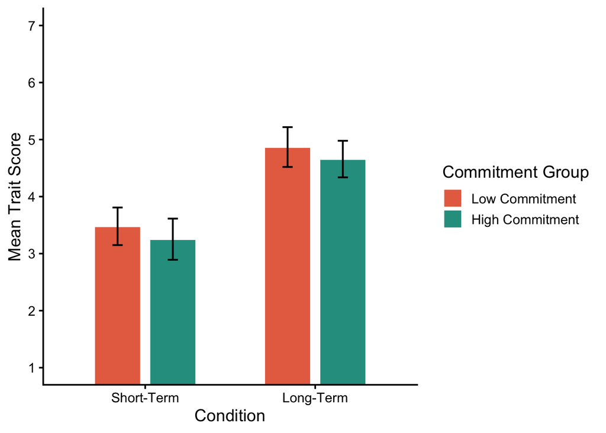

```r
p_trait_condition_commit_bar <- ggplot(
  as.data.frame(emmeans(a2_trait_commit, ~ condition * commit_msplit)),
  aes(
    x = condition,
    y = emmean,
    fill = commit_msplit
  )
) +
  geom_col(
    position = position_dodge(width = 0.65),
    width = 0.55,
    color = "white"
  ) +
  geom_errorbar(
    aes(
      ymin = lower.CL,
      ymax = upper.CL
    ),
    position = position_dodge(width = 0.65),
    width = 0.12,
    linewidth = 0.7
  ) +
  labs(
    x = "Condition",
    y = "Mean Trait Score",
    fill = "Commitment Group"
  ) +
  scale_fill_manual(
    values = c(
      "Low Commitment" = "#E76F51", # YOU CAN CHANGE THESE HEX VALUES TO MATCH YOUR POSTER!
      "High Commitment" = "#2A9D8F"
    )
  ) +
  scale_y_continuous(
    breaks = seq(1, 7, 1)
  ) +
  coord_cartesian(
    ylim = c(1, 7)
  ) +
  theme_classic(
    base_size = 14
  )

p_trait_condition_commit_bar
```

This figure shows trait scores by relationship condition and commitment group, with error bars showing confidence intervals.

### Export Figures

```r
if (!dir.exists("figures")) {
  dir.create("figures")
}

ggsave(
  filename = "figures/trait_condition_sex_interaction_plot.svg",
  plot = p_trait_condition_sex_bar,
  width = 7,
  height = 5
)

ggsave(
  filename = "figures/trait_condition_commitment_interaction_plot.svg",
  plot = p_trait_condition_commit_bar,
  width = 7,
  height = 5
)
```

The code above saves both plots into the figures folder for later use.

## Results Summary

Overall, this report tests whether partner trait ratings differ based on relationship context, sex, and commitment readiness.